使用之前的資料探討球員關鍵時刻的出手率與其其他項目之關係

關鍵時刻出手率之定義：在最後一節剩餘時間<=60且滿足以下其中一條件

以下球員指考慮平常出手律高於7%的球員

1.剩餘時間 > 30 and 分差 <= 10

2.剩餘時間 > 20 and 分差 <= 8

3.分差 <= 7 出手率=自己出手數/總隊上總出手數

根據HW1跑出之資料延續探討關係

Percentage : 平常出手率

sp_percentage：關鍵時刻出手率

pp = sp_percentage / Percentage : 關鍵時刻出手增加率

```r
library(tidyverse)
```

```r
library(ggplot2)
data_final <- read.csv("res.csv")
data_final <- data_final %>% mutate(pp = sp_percentage / Percentage)
head(data_final)
```

```
##   X              name   Salary Height   FG. Percentage sp_percentage
## 1 1    A. Aminu - POR  6957105     81 0.433 0.07985469   0.080000000
## 2 2  A. Bradley - MEM 12000000     74 0.408 0.09860268   0.008196721
## 3 3 A. Drummond - DET 25434263     83 0.533 0.16122449   0.156250000
## 4 4   A. Gordon - ORL 21590909     81 0.449 0.13946413   0.146341463
## 5 5  A. Horford - BOS 28928710     82 0.535 0.09749236   0.110091743
## 6 6      A. Len - ATL  4350000     85 0.494 0.08010899   0.064102564
##           pp
## 1 1.00181972
## 2 0.08312878
## 3 0.96914557
## 4 1.04931254
## 5 1.12923459
## 6 0.80019187
```

關件時刻出手增加律和球員之薪水有正相關

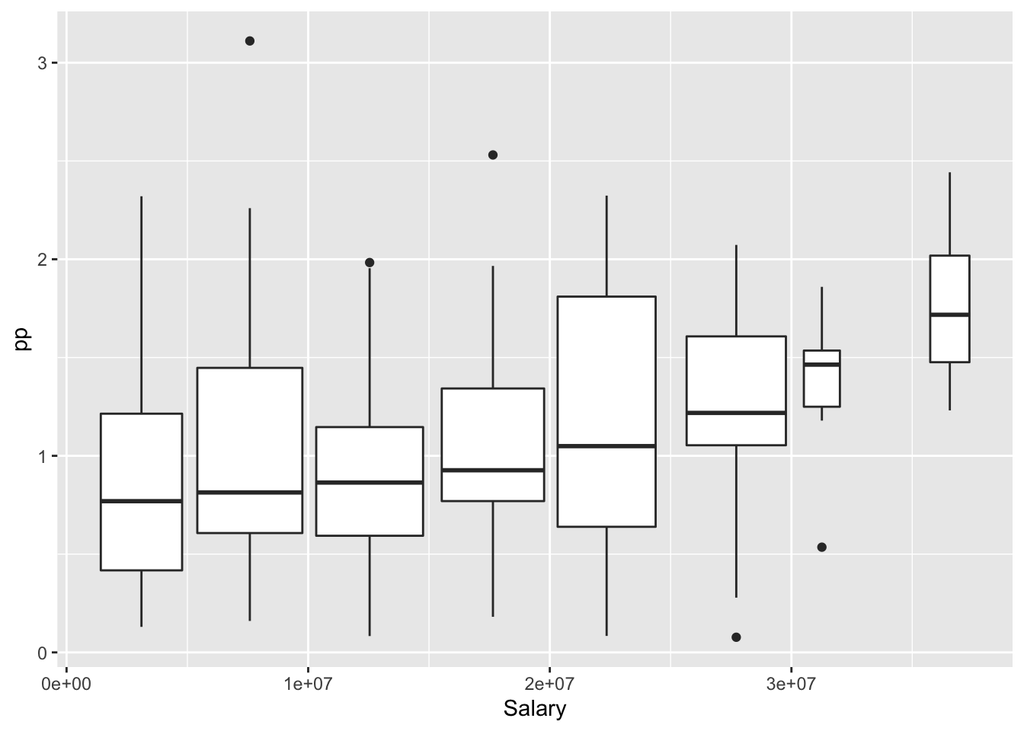

```r
ggplot(data = data_final) + geom_boxplot(mapping = aes(x = Salary, y = pp, group = cut_width(Salary, 5000000, boundary = 0)))
```

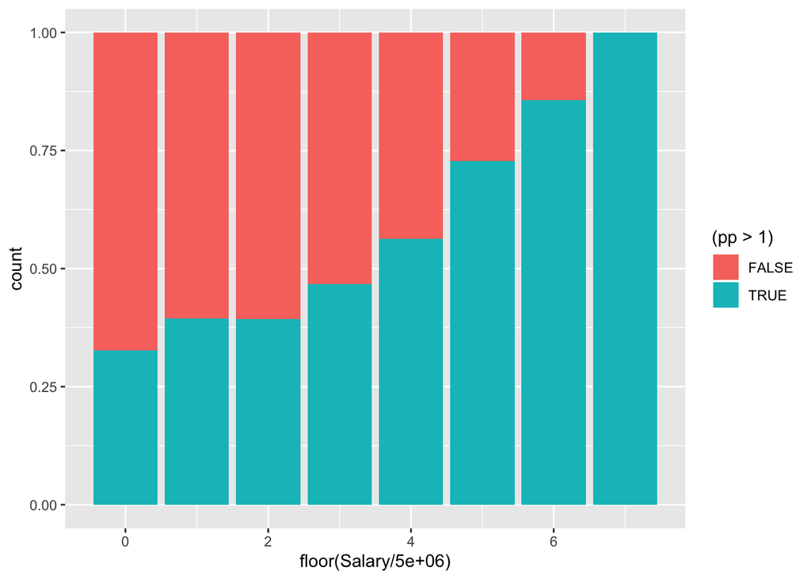

```r
ggplot(data = data_final) + geom_bar(mapping = aes(x = floor(Salary/5000000), fill = (pp > 1)), position = "fill")
```

若將球員大致依身高分場上位置，可得第一二矮的關件時刻出手增加律較高

推測關鍵時刻比較常將球給後衛

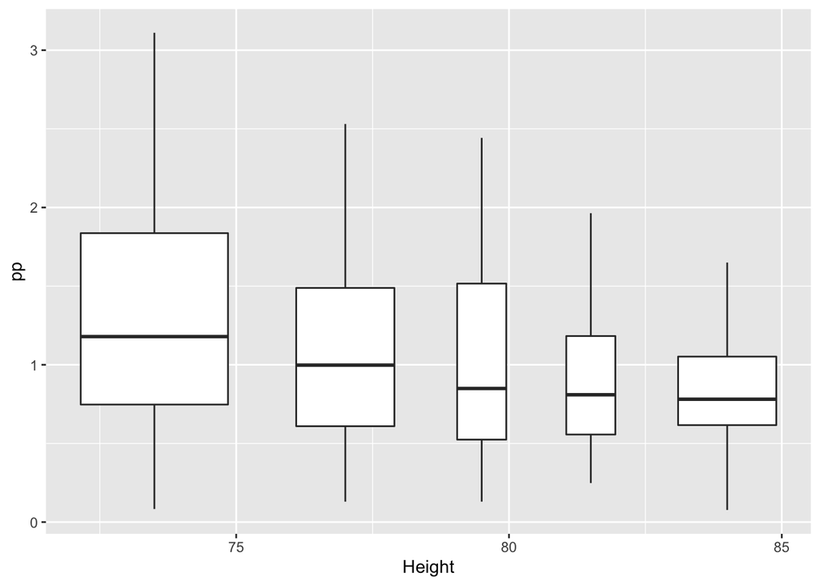

```r
ggplot(data = data_final) + geom_boxplot(mapping = aes(x = Height, y = pp, group = cut_number(Height, 5, boundary = 72)))
```

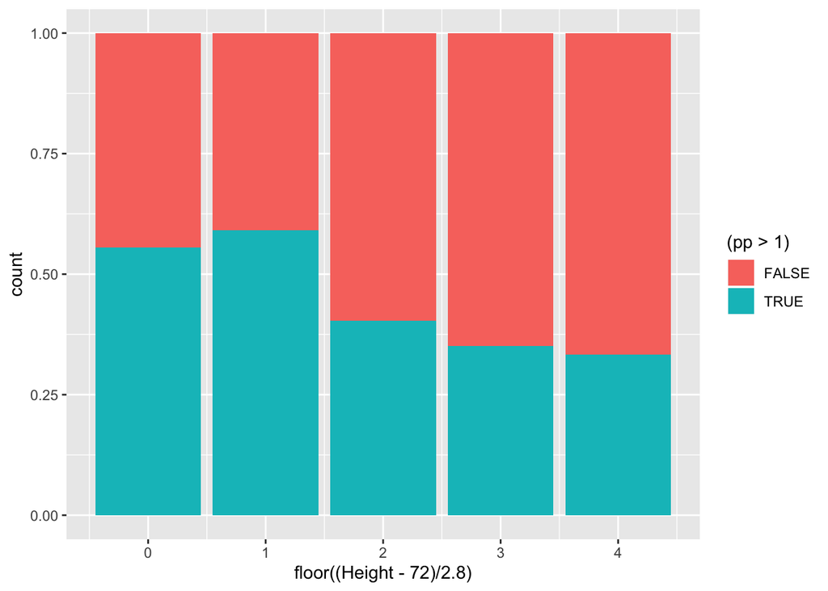

```r
ggplot(data = data_final) + geom_bar(mapping = aes(x = floor((Height-72)/2.8), fill = (pp > 1)), position = "fill")
```

關件時刻出手增加律和總體命中律沒有成正向關

推測可能會將很多球交給球星處理，卻又被嚴防

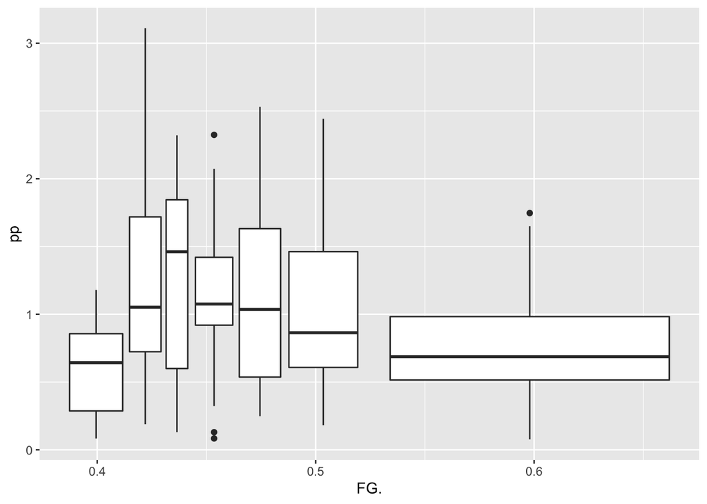

```r
ggplot(data = data_final) + geom_boxplot(mapping = aes(x = FG., y = pp, group = cut_number(FG., 7, boundary = 0.386)))
```

關件時刻出手律和平常出手律大致上有正相關

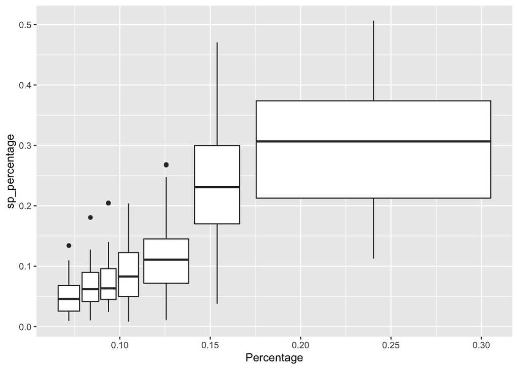

```r
ggplot(data = data_final) + geom_boxplot(mapping = aes(x = Percentage, y = sp_percentage, group = cut_number(Percentage, 7, boundary = 0)))
```

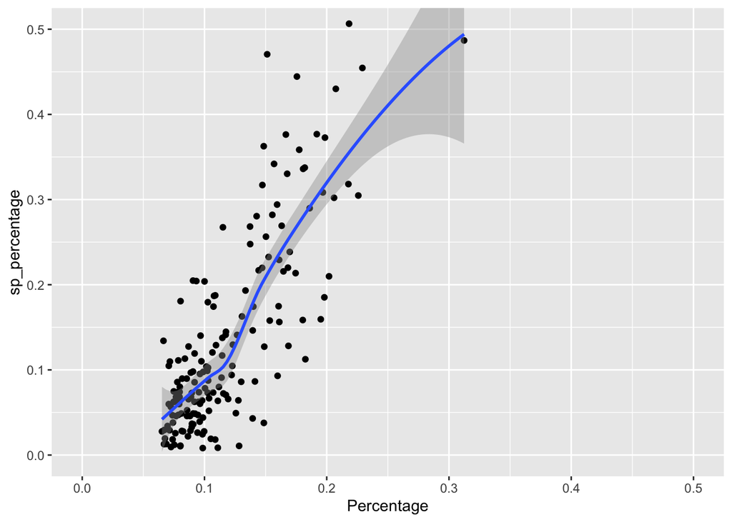

```r
ggplot(data = data_final) + geom_point(mapping = aes(x = Percentage, y = sp_percentage)) + geom_smooth(mapping = aes(x = Percentage, y = sp_percentage)) + coord_cartesian(xlim = c(0, 0.5), ylim = c(0, 0.5))
```

結論：大體上不會有所謂“奇兵”，對於平常出手律、年薪，就決定關鍵時刻的球權，雖然出手者命中率不見得最高，但還是會被信任。